# Lab 9: Plotting categorical data and the Chi-square test

As always, we will start by creating a new R script called LastName_Lab09. **Make sure that when you open R Studio, you open it by double clicking on your GEOG316 R project.** The file extension is .Rproj. By opening the project and then opening (or creating) a script from inside the project you ensure that your working directory is correctly specified. Don’t forget to load the `tidyverse`!

# 1 Categorical data

We have looked at categorical data in terms of defining groups like for a t-test. Is the average height of men different than the average height of women? Is the average length of salmon that live in streams within 5 miles of a power plant different than the average length of salmon that do not? The data in both of these questions have something in common: they are continuous variables (height, length) that are defined by two different groups, or categories. But what happens if you don’t have any continuous data? What happens if you only have categorical characteristics?

For this lab we are going to use a dataset called `titanic` that is the complete passenger manifest of the RMS Titanic that sunk in the North Atlantic Ocean in 1912 after hitting an iceberg. Notably the ship carried enough life boats for only half the passengers. Let’s see if there is any relationship between passenger class and whether or not they survived the disaster.

First, download `titanic.txt` and save it in your Datasets folder. Then, load the dataset using `read_tsv()`. This is like `read_csv()` but for tab-delimited files rather than comma-delimited files. Take a look at the dataframe to get a sense of the variables.

```r
dat <- read_tsv("Datasets/titanic.txt")
```

# 2 Plotting categorical data

Just like continuous data, you can learn a lot by simply plotting categorical data. Even though we are dealing with two categorical variables—class and survival—there are counts associated with those categories and counts are discrete numeric variables. Because they are numeric, we can plot them.

A very common type of plot for categorical data is a bar chart. In a bar chart, the height of the bar is proportional to the number of observations in each category. Bar charts are similar to histograms in that they show the count on the y-axis but instead of a continuous variable on the x-axis they show a discrete variable. Let’s make a simple bar chart.

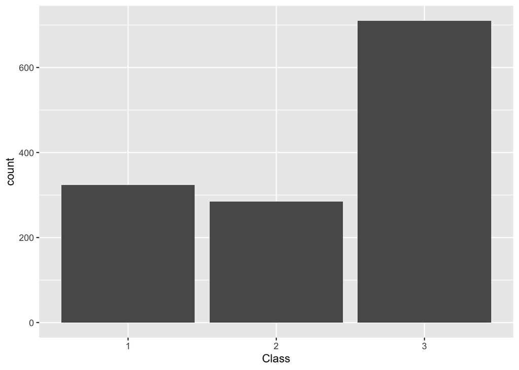

```r
# != means 'not equal to'
# select - selects columns based on criteria
# filter - selects rows based on criteria
class.survival <- dat %>%
  select(Class, Survived) %>%
  filter(Class != "Crew")

ggplot(class.survival) +
  geom_bar(aes(x = Class))
```

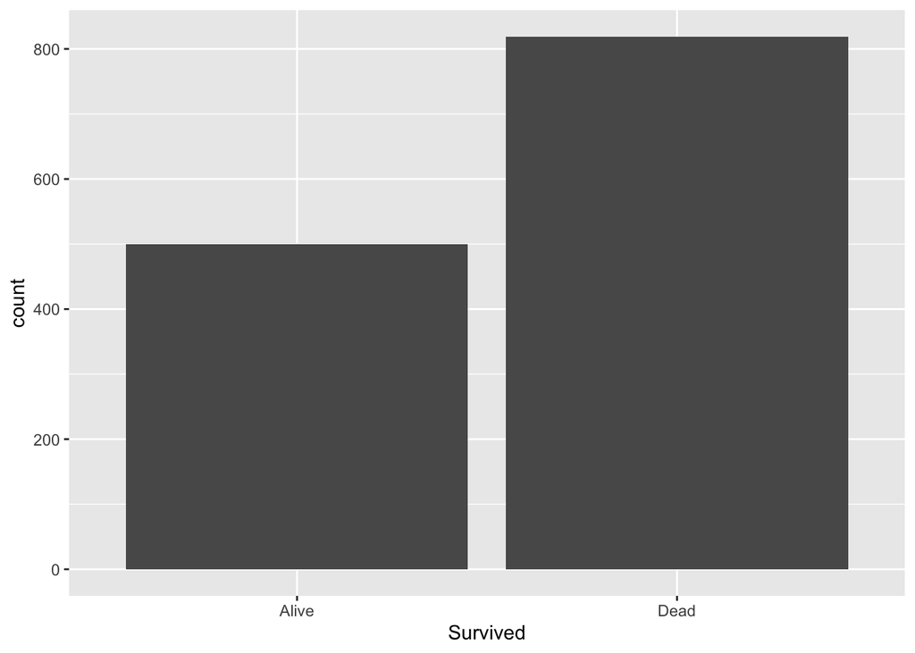

```r
ggplot(class.survival) +
  geom_bar(aes(x = Survived))
```

You can see that most of the passengers were third class, followed by first class. At the time, the Titanic was considered the pinnacle of luxury and first class passengers would have been wealthy, elite members of society. You can also see that most people did not survive the disaster.

You can also make a bar chart that displays two categorical variables. Within each class we can look at how many people survived, and within those who survived we can see what the class make up was.

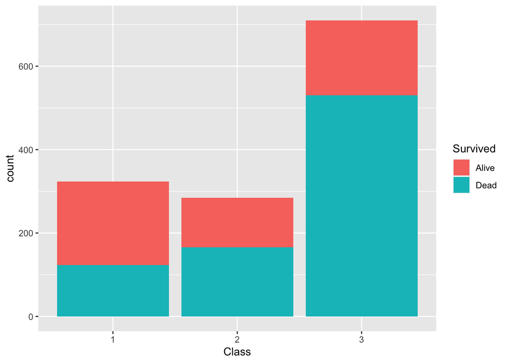

```r
ggplot(class.survival) +
  geom_bar(aes(x = Class, fill = Survived))
```

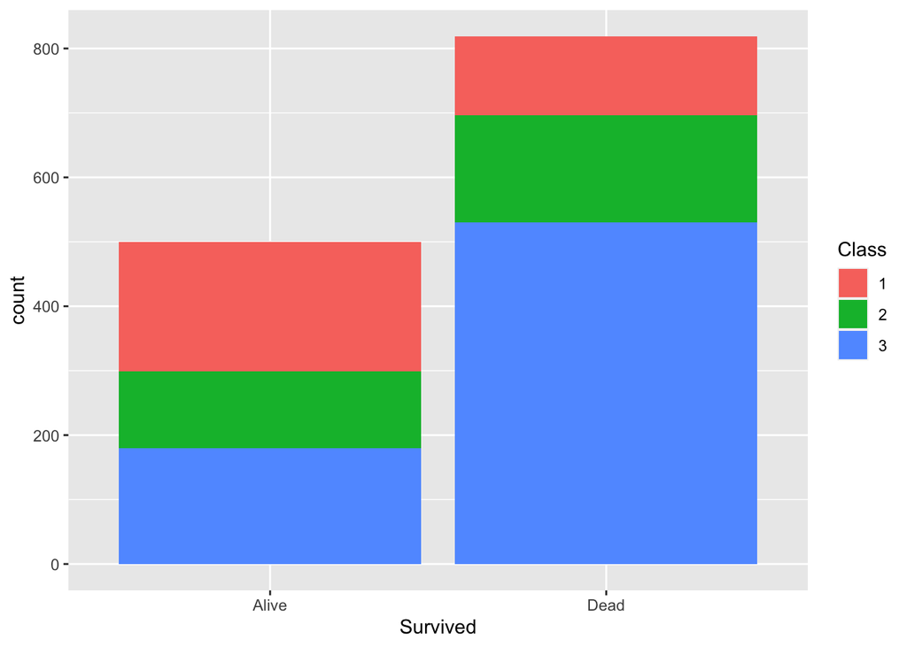

```r
ggplot(class.survival) +
  geom_bar(aes(x = Survived, fill = Class))
```

You can also show the bars next to each other instead of stacked on top of each other.

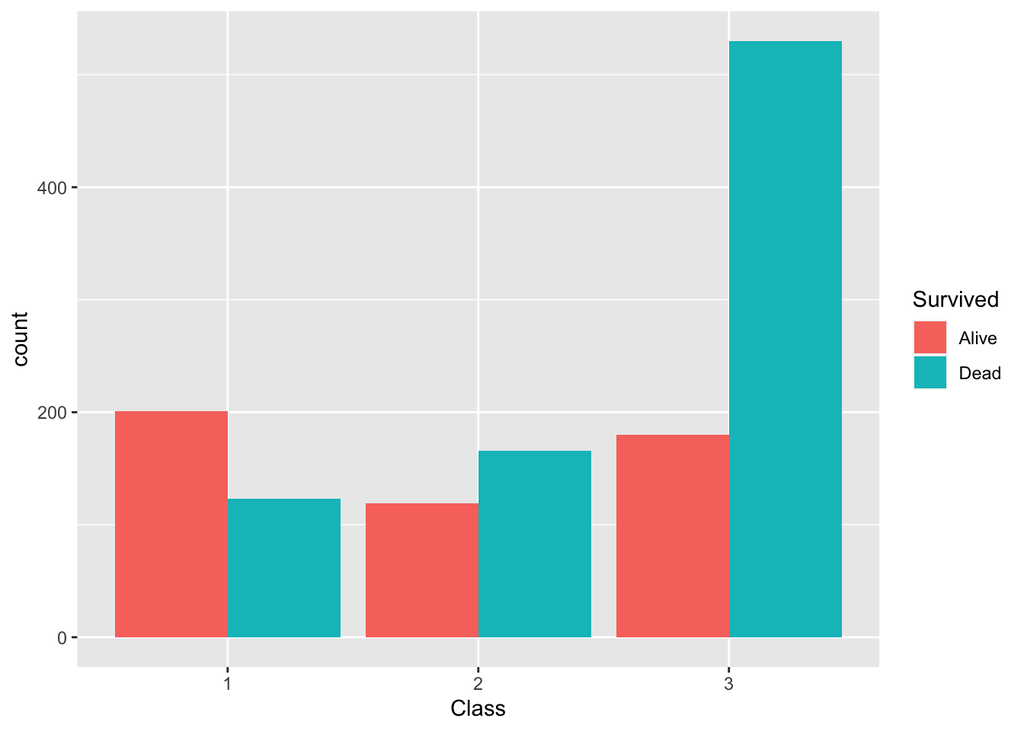

```r
ggplot(class.survival) +
  geom_bar(aes(x = Class, fill = Survived), position = position_dodge())
```

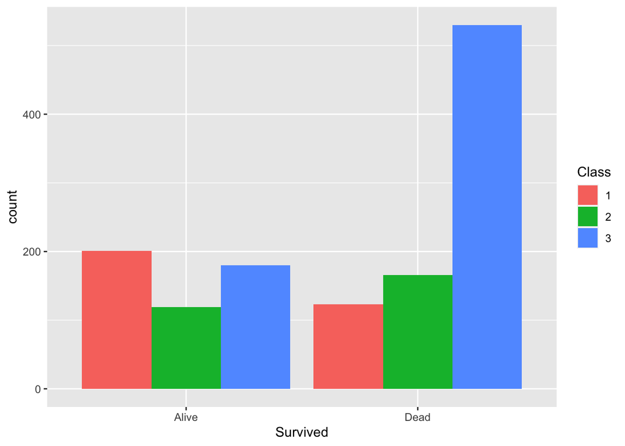

```r
ggplot(class.survival) +
  geom_bar(aes(x = Survived, fill = Class), position = position_dodge())
```

And instead of counts you could display proportions. You can even label the y-axis with percentages instead of proportions if you like.

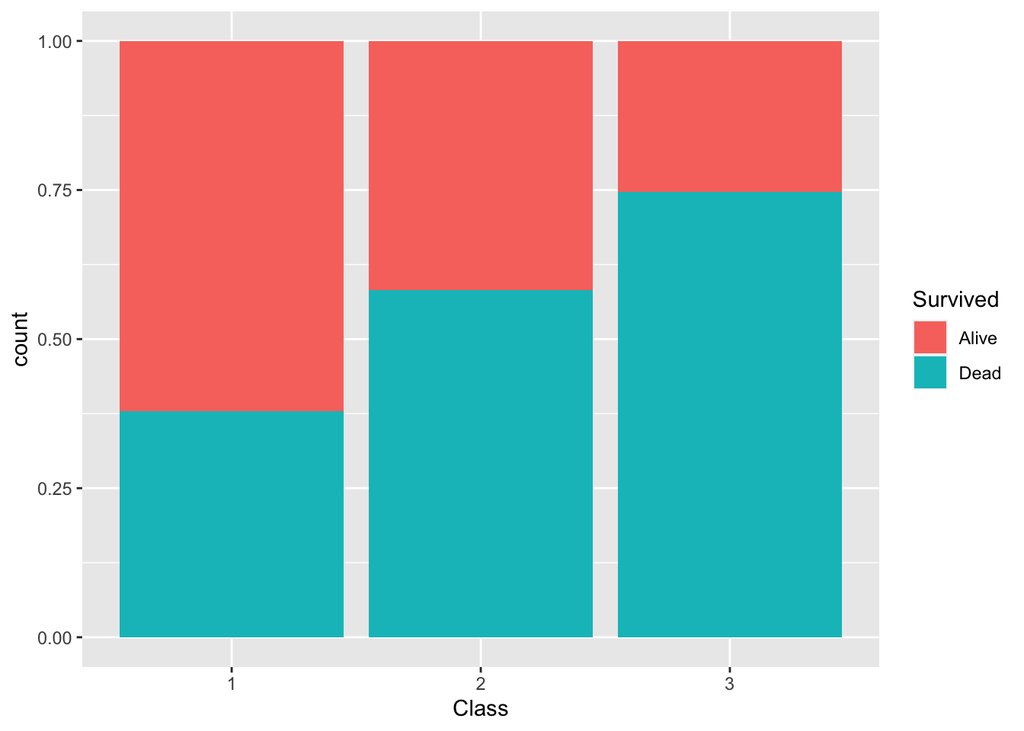

```r
ggplot(class.survival) +
  geom_bar(aes(x = Class, fill = Survived), position = "fill")
```

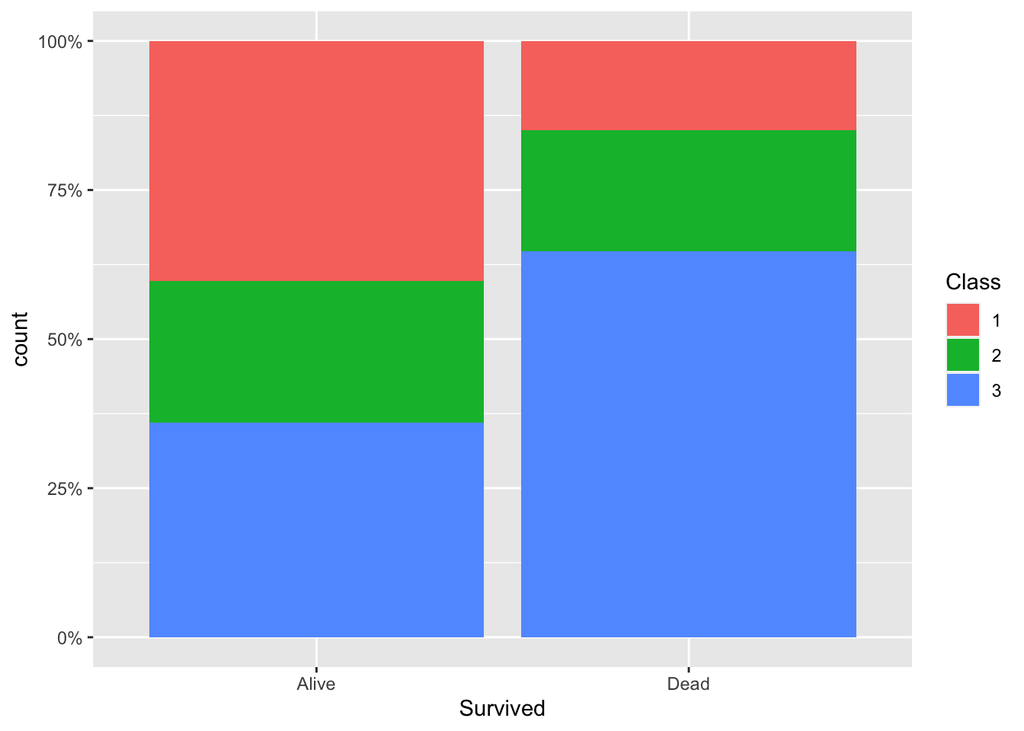

```r
ggplot(class.survival) +
  geom_bar(aes(x = Survived, fill = Class), position = "fill") +
  scale_y_continuous(labels = scales::percent)
```

And remember, you can always change the colors.

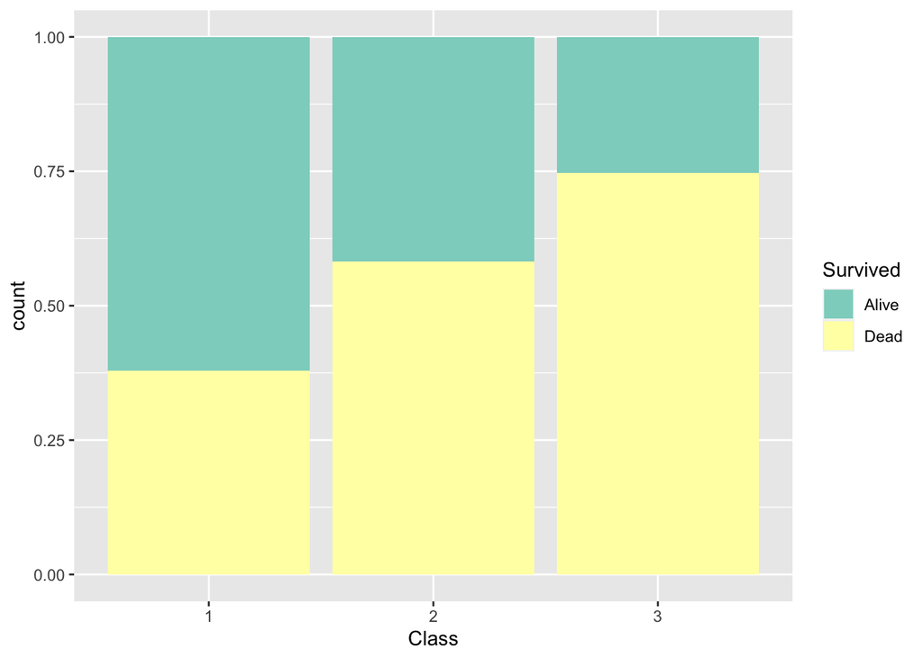

```r
# From https://colorbrewer2.org/ the brewer palettes are especially designed
# for making maps (which you can totally do in R!)
ggplot(class.survival) +
  geom_bar(aes(x = Class, fill = Survived), position = "fill") +
  scale_fill_brewer(palette = "Set3")
```

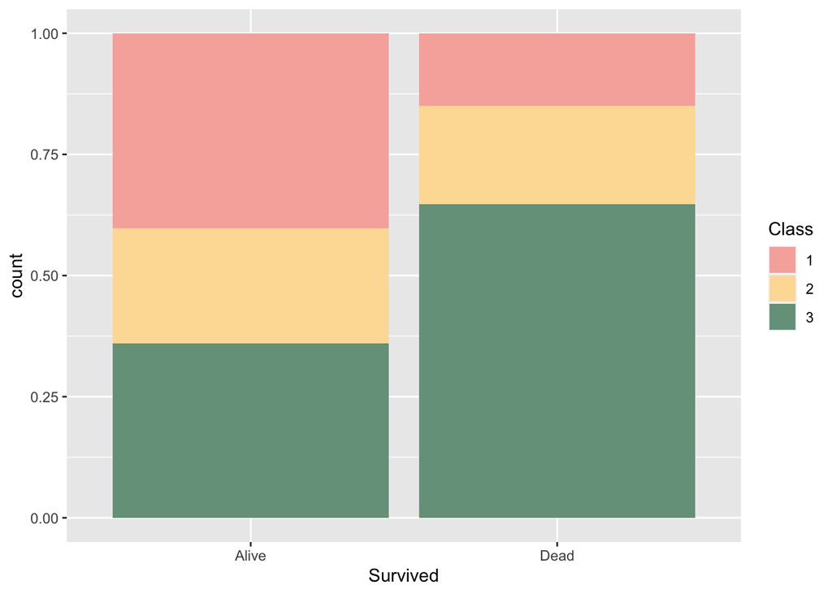

```r
# These are called hex codes
royal.tenenbaums <- c("#F7B0AA", "#FDDDA4", "#76A08A")

ggplot(class.survival) +
  geom_bar(aes(x = Survived, fill = Class), position = "fill") +
  scale_fill_discrete(type = royal.tenenbaums)
```

From examining these plots, it certainly seems possible that a higher percentage of first class passengers survived than the other classes. But like anything else, we need statistics to tell for sure. Well, nothing is for sure, but we want to be **reasonably** sure.

# 3 Chi-square test

The chi-square test—pronounced “kai” and also written $\chi^2$ test— compares the frequencies of the data to what would be expected if the null hypothesis were true. There are two kinds: the goodness-of-fit test and the test for independence.

## 3.1 Goodness-of-fit test

The goodness-of-fit test tests one categorical variable against an expected distribution. Let’s try with our Titanic data. There were lifeboats for half the passengers. If the lifeboats were filled to capacity, half the passengers would have survived so we would expect frequencies of 50% alive and 50% dead. First, let’s look at the actual frequencies using the `table()` function.

```r
table(class.survival$Survived)
```

```
##
## Alive  Dead
##   500   819
```

Doesn’t look like the lifeboats got utilized properly. We’ll use the chi-square test to tell us the likelihood that the observed frequencies came from a different distribution than what was expected. The `chisq.test()` takes the frequencies as the variables so we can run it on the frequency table rather than the dataframe. We could also use a vector of frequencies.

```r
exp.freq <- c(0.5, 0.5)

# p is the expected probabilities
chisq.test(table(class.survival$Survived), p = exp.freq)
```

```
##
##  Chi-squared test for given probabilities
##
## data:  table(class.survival$Survived)
## X-squared = 77.15, df = 1, p-value < 2.2e-16
```

The higher the chi-square test statistic—shown as X-squared—the less likely it is that the observed frequencies match the expected frequencies. Our test statistic corresponds to a p-value of less than 0.001 which means that it is highly unlikely that the lifeboats were used properly. Of course, that’s pretty easy to see when you only have two categories.

In 2008 the Mars candy company published the color breakdown of M&Ms candy as such:

| Color | Percent |
| --- | --- |
| Blue | 24 |
| Orange | 20 |
| Green | 16 |
| Yellow | 14 |
| Red | 13 |
| Brown | 13 |

A PhD statistician named Rick Wicklin who happened to be around a lot of M&Ms decided to test if these percentages were accurate or not. He randomly sampled M&Ms every day for several weeks until he had 712 candies. Then he sorted them by color and calculated the frequencies.

| Color | Percent |
| --- | --- |
| Blue | 18.7 |
| Orange | 18.7 |
| Green | 19.5 |
| Yellow | 14.5 |
| Red | 15.1 |
| Brown | 13.5 |

He then used the chi-square test to determine whether or not the M&M colors were really distributed like Mars said they were.

First we need to calculate the frequencies by multiplying the observed percentages by 712 (the sample size). Then we can use `chisq.test()` to compare the observed frequencies to the expected.

```r
observed <- c(0.187, 0.187, 0.195, 0.145, 0.151, 0.135)
obs.freq <- 712 * observed

expected <- c(0.24, 0.20, 0.16, 0.14, 0.13, 0.13)
chisq.test(obs.freq, p = expected)
```

```
##
##  Chi-squared test for given probabilities
##
## data:  obs.freq
## X-squared = 17.066, df = 5, p-value = 0.004377
```

Again, the p-value for the test statistic is very low, less than 0.005, so we can reject the null hypothesis that the sampled M&Ms were distributed like Mars said they should be. And that’s just what Rick Wicklin did! He contacted Mars to see what was up. [Here’s the rest of the story](https://qz.com/918008/the-color-distribution-of-mms-as-determined-by-a-phd-in-statistics/).

## 3.2 Test for independence

The chi-square test for independence compares two categorical variables against the frequencies that would be expected if there were no relationship between the variables. This test is based on contingency tables which are two-way tables of frequencies. The totals in the margins show the frequencies of each category. You can also display them as proportions. Here are is class breakdown of who survived.

```r
observed.freq <- table(class.survival)
addmargins(observed.freq)
```

```
##      Survived
## Class Alive Dead  Sum
##   1     201  123  324
##   2     119  166  285
##   3     180  530  710
##   Sum   500  819 1319
```

```r
observed.prop <- prop.table(observed.freq)
addmargins(observed.prop)
```

```
##      Survived
## Class      Alive       Dead        Sum
##   1   0.15238817 0.09325246 0.24564064
##   2   0.09021986 0.12585292 0.21607278
##   3   0.13646702 0.40181956 0.53828658
##   Sum 0.37907506 0.62092494 1.00000000
```

If there was no class bias in who survived, the 500 people who survived would be spread proportionally through the classes. Here are the expected frequencies if there was no relationship between class and survival:

```
##      Survived
## Class  Alive   Dead  Sum
##   1   122.82 201.18  324
##   2   108.04 176.96  285
##   3   269.14 440.86  710
##   Sum 500.00 819.00 1319
```

```
##      Survived
## Class      Alive      Dead       Sum
##   1   0.09311600 0.1525246 0.2456406
##   2   0.08191054 0.1341622 0.2160728
##   3   0.20404852 0.3342381 0.5382866
##   Sum 0.37907506 0.6209249 1.0000000
```

We’ll compare those frequencies using the chi-square test for independence. Again, we need to input the frequency table rather than the dataframe itself. We could also use two vectors of frequencies. The `chisq.test()` will calculate the expected frequencies for us, so we do not need to specify **p**. You can actually access the expected values from the chi-square test similar to the last lab where we extracted the confidence interval from the `t.test`.

```r
test <- chisq.test(observed.freq)
test
```

```
##
##  Pearson's Chi-squared test
##
## data:  observed.freq
## X-squared = 129.49, df = 2, p-value < 2.2e-16
```

```r
test$expected
```

```
##      Survived
## Class    Alive     Dead
##     1 122.8203 201.1797
##     2 108.0364 176.9636
##     3 269.1433 440.8567
```

The p-value is less than 0.001, indicating that we should reject the null hypothesis that there was no relationship between class and survival when the Titanic sunk.

# 4 Exercises

1. The [General Social Survey](https://gssdataexplorer.norc.org/) has been monitoring social change in America since 1972 and is a great data resource. This data is from 2016 and gives the number of children a person has and their level of happiness in their marriage. The data has been subset to contain only people with 3 or fewer children. Load the dataset **GSS.csv**. You will want to change the `Children` column to a factor using `mutate(Children = as.factor(Children))`.
2. Using the GSS dataset, create a bar chart for the number of children. Have the fill represent the happiness in marriage and make the bars side by side instead of stacked. If you want, change the color palette!
3. Using the GSS dataset, create a bar chart for marriage happiness. Have the fill represent the number of children and instead of counts display proportions. Change the color palette.
4. For each category of marriage happiness, what are the frequencies of people with zero children?
5. Filter your data to contain only people with zero children. If you don’t remember how to do this, refer back to the Titanic example. Remember that in R if you want something that is equal to something else you use two equals signs (==). One equals sign (=) sets something equal to something else.
6. Using the chi-square test, are the frequencies of marriage happiness for people with no children what we would expect? Use the p-value to decide.
7. Using the chi-square test, are the frequencies of children and marriage happiness what we would expect if there were no relationship between the two?